# Analyzing the Human Impact of Climate Events in the United States

Michael Connolly

Saturday, January 24, 2015

## Synopsis

You may ask yourself, across the United Status, which types of events are most harmful with respect to population health? Relatedly, which events also have the greatest economic consequences?

Using the NOAA Storm Database, it is clear that the most negatively impactful climate events on human health and prosperity is the tornado. If you see a twister coming, back the truck up and skeedaddle, because it’s about to go down, y’all.

## Data Processing

The data we used for this analysis comes from U.S. National Oceanic and Atmospheric Administration’s (NOAA) storm database, which can be found at this location: https://d396qusza40orc.cloudfront.net/repdata%2Fdata%2FStormData.csv.bz2. After downloading the file to our working directory, we loaded the file into memory and calculated the total of all deaths, injuries, and property damage for all climate events in the database.

```r
library(sqldf)
dataFile <- read.csv("repdata-data-StormData.csv.bz2")

allDeaths <- sqldf("SELECT SUM(FATALITIES) as FATALITIES_TOTAL FROM dataFile")
allInjuries <- sqldf("SELECT SUM(INJURIES) as INJURIES_TOTAL FROM dataFile")
allPropertyDamage <- sqldf("SELECT SUM(PROPDMG) as PROPDMG_TOTAL FROM dataFile")

topTenDeaths <- sqldf("SELECT EVTYPE, SUM(FATALITIES) AS FATALITIES_TOTAL FROM dataFile GROUP BY EVTYPE ORDER BY FATALITIES_TOTAL DESC LIMIT 10")
topTenInjuries <- sqldf("SELECT EVTYPE, SUM(INJURIES) AS INJURIES_TOTAL FROM dataFile GROUP BY EVTYPE ORDER BY INJURIES_TOTAL DESC LIMIT 10")
topTenPropertyDamage <- sqldf("SELECT EVTYPE, SUM(PROPDMG) AS PROPDMG_TOTAL FROM dataFile GROUP BY EVTYPE ORDER BY PROPDMG_TOTAL DESC LIMIT 10")

tornadoDeaths <- sqldf("SELECT COUNTYNAME, STATE, SUM(FATALITIES) AS FATALITIES_TOTAL FROM dataFile WHERE EVTYPE='TORNADO' GROUP BY COUNTY ORDER BY FATALITIES_TOTAL DESC LIMIT 20")
tornadoInjuries <- sqldf("SELECT COUNTYNAME, STATE, SUM(INJURIES) AS INJURIES_TOTAL FROM dataFile WHERE EVTYPE='TORNADO' GROUP BY COUNTY ORDER BY INJURIES_TOTAL DESC LIMIT 20")
tornadoPropertyDamage <- sqldf("SELECT COUNTYNAME, STATE, SUM(PROPDMG) AS PROPDMG_TOTAL FROM dataFile WHERE EVTYPE='TORNADO' GROUP BY COUNTY ORDER BY PROPDMG_TOTAL DESC LIMIT 20")
```

## Results

There are three non-controversial ways to measure the impact of different climate events over the course of time our data has been collected: human fatalities, human injuries, and property damage. All three measurements show that the dominant events are tornados.

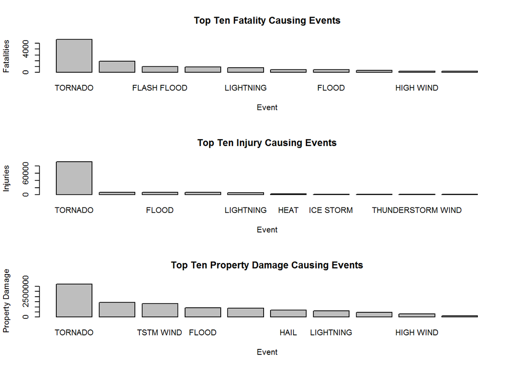

```r
par(mfrow=c(3,1))
barplot(topTenDeaths$FATALITIES_TOTAL, names = topTenDeaths$EVTYPE,
        xlab = "Event", ylab = "Fatalities",
        main = "Top Ten Fatality Causing Events")
barplot(topTenInjuries$INJURIES_TOTAL, names = topTenInjuries$EVTYPE,
        xlab = "Event", ylab = "Injuries",
        main = "Top Ten Injury Causing Events")
barplot(topTenPropertyDamage$PROPDMG_TOTAL, names = topTenPropertyDamage$EVTYPE,
        xlab = "Event", ylab = "Property Damage",
        main = "Top Ten Property Damage Causing Events")
```

```r
tornadoDeaths
```

```
##     COUNTYNAME STATE FATALITIES_TOTAL
## 1       DEKALB    AL              260
## 2       MOBILE    AL              224
## 3         EDDY    ND              144
## 4      CARROLL    VA              122
## 5        LAMAR    MS              119
## 6        MOORE    NC              116
## 7     MCLENNAN    TX              114
## 8      ELKHART    IN              107
## 9      SHERMAN    NE              100
## 10     DE SOTO    LA               99
## 11      MONROE    MI               94
## 12       CADDO    OK               93
## 13 SCHENECTADY    NY               92
## 14      HARRIS    GA               92
## 15       GRANT    OK               91
## 16      ORANGE    FL               90
## 17   CLEVELAND    NC               89
## 18    JENNINGS    IN               89
## 19    DAVIDSON    NC               87
## 20      OTSEGO    NY               76
```

```r
tornadoInjuries
```

```
##     COUNTYNAME STATE INJURIES_TOTAL
## 1       DEKALB    AL           2466
## 2        JONES    MS           2258
## 3       MOBILE    AL           2129
## 4         EDDY    ND           2062
## 5        LAMAR    MS           2010
## 6     DAVIDSON    NC           2006
## 7      DE SOTO    LA           1972
## 8        MOORE    NC           1934
## 9      WICHITA    TX           1845
## 10       GRANT    OK           1676
## 11     BROWARD    FL           1492
## 12   MCPHERSON    KS           1455
## 13       AIKEN    SC           1431
## 14     CARROLL    VA           1366
## 15   MCCURTAIN    OK           1289
## 16     SHERMAN    NE           1283
## 17      OTSEGO    NY           1281
## 18 SCHENECTADY    NY           1227
## 19       CADDO    OK           1185
## 20    JENNINGS    IN           1166
```